# netcdf_to_brick_projected

Samantha Andrews

# Overview

Mass netCDF to raster brick, and then reprojection…

A note to anyone who might happen to stumble across this… I am a beginner in R and have had no exposure to similar languages. I don’t know what I’m doing. The code herein is unlikely to be elegant and there area probably more efficient ways of running the code.

SAM - YOU MIGHT WANT TO [PARALLEL PROCESS FOR THE WHOLE DATASET..](https://cran.r-project.org/web/packages/doParallel/vignettes/gettingstartedParallel.pdf) and also [here](https://gis.stackexchange.com/questions/253618/r-multicore-approach-to-extract-raster-values-using-spatial-points)

# Package dependencies

You can load them using the following code which uses a function called [ipak](https://gist.github.com/stevenworthington/3178163). Note this function checks to see if the packages are installed first.

```r
packages <- c("ncdf4", "sp")
source("../src/ipak.R")
ipak(packages)
suppressMessages(ipak)
```

Ok first get a list of netcdfs in the folder…

```r
netcdf_list <- list.files("../data/env/netcdf", pattern = '*.nc', full.names = TRUE)
```

ok now create a raster brick for each netcdf, project, and assing the same file name as the netCDF

```r
no_netcdf <- length(netcdf_list) #for the loop - need to know how many files to cycle through
netcdf_name <- list.files("../data/env/netcdf", pattern = '*.nc', full.names = FALSE) #false means the path is not included
library (ncdf4)
for (i in 1:no_netcdf) {
  print(netcdf_name[i]) #this just prings the name of the netCDF R is working on
  temp_brick <- brick(netcdf_list[i], lvar = 4)
  temp_brick <- projectRaster(temp_brick, aea) #aea is an existing raster in the projection I want that I created (environmental_data_preperation)
  assign(netcdf_name[i], temp_brick) #this asigns the netCDF name to the raster brick
}
```

```
[1] "1998_01_mlp.nc"
```

```
no non-missing arguments to min; returning Infno non-missing arguments to max; returning -Inf
```

```
[1] "1998_01_salinity.nc"
```

[output not shown]

```
[1] "1998_01_ssh.nc"
```

```
no non-missing arguments to min; returning Infno non-missing arguments to max; returning -Inf
```

```
[1] "1998_01_temp.nc"
```

[output not shown]

```
[1] "1998_02_mlp.nc"
```

```
no non-missing arguments to min; returning Infno non-missing arguments to max; returning -Inf
```

```
[1] "1998_02_salinity.nc"
```

[output not shown]

```
[1] "1998_02_ssh.nc"
```

```
no non-missing arguments to min; returning Infno non-missing arguments to max; returning -Inf
```

```
[1] "1998_02_temp.nc"
```

[output not shown]

```
[1] "1998_03_mlp.nc"
```

```
no non-missing arguments to min; returning Infno non-missing arguments to max; returning -Inf
```

```
[1] "1998_03_salinity.nc"
```

[output not shown]

```
[1] "1998_03_ssh.nc"
```

```
no non-missing arguments to min; returning Infno non-missing arguments to max; returning -Inf
```

```
[1] "1998_03_temp.nc"
```

[output not shown]

```
[1] "1998_04_mlp.nc"
```

```
no non-missing arguments to min; returning Infno non-missing arguments to max; returning -Inf
```

```
[1] "1998_04_salinity.nc"
```

[output not shown]

```
[1] "1998_04_ssh.nc"
```

```
no non-missing arguments to min; returning Infno non-missing arguments to max; returning -Inf
```

```
[1] "1998_04_temp.nc"
```

[output not shown]

```
[1] "1998_05_mlp.nc"
```

```
no non-missing arguments to min; returning Infno non-missing arguments to max; returning -Inf
```

```
[1] "1998_05_salinity.nc"
```

[output not shown]

```
[1] "1998_05_ssh.nc"
```

```
no non-missing arguments to min; returning Infno non-missing arguments to max; returning -Inf
```

```
[1] "1998_05_temp.nc"
```

[output not shown]

```
[1] "1998_06_mlp.nc"
```

```
no non-missing arguments to min; returning Infno non-missing arguments to max; returning -Inf
```

```
[1] "1998_06_salinity.nc"
```

[output not shown]

```
[1] "1998_06_ssh.nc"
```

```
no non-missing arguments to min; returning Infno non-missing arguments to max; returning -Inf
```

```
[1] "1998_06_temp.nc"
```

[output not shown]

```
[1] "1998_07_mlp.nc"
```

```
no non-missing arguments to min; returning Infno non-missing arguments to max; returning -Inf
```

```
[1] "1998_07_salinity.nc"
```

[output not shown]

```
[1] "1998_07_ssh.nc"
```

```
no non-missing arguments to min; returning Infno non-missing arguments to max; returning -Inf
```

```
[1] "1998_07_temp.nc"
```

[output not shown]

```
[1] "1998_08_mlp.nc"
```

```
no non-missing arguments to min; returning Infno non-missing arguments to max; returning -Inf
```

```
[1] "1998_08_salinity.nc"
```

[output not shown]

```
[1] "1998_08_ssh.nc"
```

```
no non-missing arguments to min; returning Infno non-missing arguments to max; returning -Inf
```

```
[1] "1998_08_temp.nc"
```

[output not shown]

```
[1] "1998_09_mlp.nc"
```

```
no non-missing arguments to min; returning Infno non-missing arguments to max; returning -Inf
```

```
[1] "1998_09_salinity.nc"
```

[output not shown]

```
[1] "1998_09_ssh.nc"
```

```
no non-missing arguments to min; returning Infno non-missing arguments to max; returning -Inf
```

```
[1] "1998_09_temp.nc"
```

[output not shown]

```
[1] "1998_10_mlp.nc"
```

```
no non-missing arguments to min; returning Infno non-missing arguments to max; returning -Inf
```

```
[1] "1998_10_salinity.nc"
```

[output not shown]

```
[1] "1998_10_ssh.nc"
```

```
no non-missing arguments to min; returning Infno non-missing arguments to max; returning -Inf
```

```
[1] "1998_10_temp.nc"
```

[output not shown]

```
[1] "1998_11_mlp.nc"
```

```
no non-missing arguments to min; returning Infno non-missing arguments to max; returning -Inf
```

```
[1] "1998_11_salinity.nc"
```

[output not shown]

```
[1] "1998_11_ssh.nc"
```

```
no non-missing arguments to min; returning Infno non-missing arguments to max; returning -Inf
```

```
[1] "1998_11_temp.nc"
```

[output not shown]

```
[1] "1998_12_mlp.nc"
```

```
no non-missing arguments to min; returning Infno non-missing arguments to max; returning -Inf
```

```
[1] "1998_12_salinity.nc"
```

[output not shown]

```
[1] "1998_12_ssh.nc"
```

```
no non-missing arguments to min; returning Infno non-missing arguments to max; returning -Inf
```

```
[1] "1998_12_temp.nc"
```

[output not shown]

just a quick test…. (also not sure why the names are wrapped in ’’)

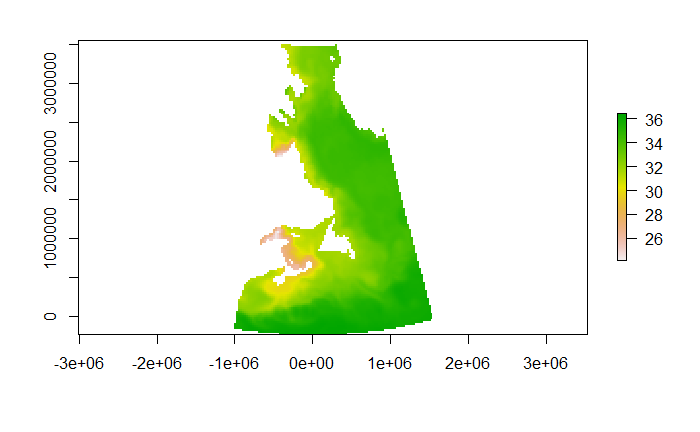

Look up year and month in the occurence data (data_aea) year = data_aea$year month = data_aea$month

the raster brick file names are character 1:4 = year charcater 6:7 = month character 9:end = env. variable name

maybe start by splitting the occurence data into year-month? Then you can search for the rasters without going through everything….

```r
library(sp)
species_obs_date <- SpatialPointsDataFrame(coords = xy, data = data_aea, proj4string = CRS("+proj=longlat +datum=WGS84 +ellps=WGS84 +towgs84=0,0,0")) #convert into a spatialpoints dataframe to do the extraction
species_obs_date <- spTransform(species_obs_date, CRS = "+proj=aea +lat_1=50 +lat_2=70 +lat_0=40 +lon_0=-60 +x_0=0 +y_0=0 +ellps=GRS80 +datum=NAD83 +units=m +no_defs") #need to reproject.... note -60 used to be -91. Changed to 'straighten up'
split(species_obs_date, paste(species_obs_date$year, species_obs_date$month))
```

[output not shown]

[output cut: 1120 more lines]

[output not shown]

```
no non-missing arguments, returning NAno non-missing arguments, returning NA
```

[output not shown]

[output cut: 155 more lines]

[output not shown]

```
no non-missing arguments, returning NAno non-missing arguments, returning NA
```

[output not shown]

[output cut: 97 more lines]

[output not shown]

just check the species_obs_date complete file in a plot

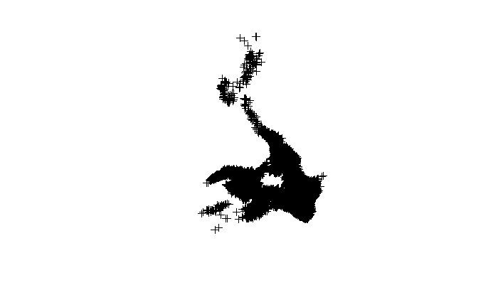

```r
plot(species_obs_date)
```

looks good…

```r
for(i in split_obs){
  print(i)
}
```

[output not shown]

hmm what now….

I want to populate the following fields in the species_obs_date spatialdf mlp salinty_1 salinity_depth ssh temp_1 temp_depth chl_1 chl_depth o2_1 o2_depth

where _1 indicates the surface layer [[1]] of each environmental variable, and depth is the == species_obs_date$depthlayerno Note mlp and ssh have only one single layer ([[1]])

netcdf_list = list of all netcdfs no_netcdf = number of netcdfs created netcdf_name = name of netcdfs - will match the name of the raster bricks too.